# draft_edit_jw

# Libraries

```r
#LIBRARIES FIGURE OUT WHICH I ACTUALLY NEED LATER
library(tidyverse)
library(GGally)
library(psych)
library(stats)
library(tidyverse)
library(dplyr)
library(tidyr)
library(ggplot2)
library(normalr)
library(GGally)
library(visdat)
library(corrplot)
```

# Data

```r
raw <- read.csv("./data/moneyball-training-data.csv")
#deselect index
raw<-raw%>%select(-INDEX)
```

# Initial Observations and Tidying

First lets look at the summary of the variables to get a feel for the data

```r
summary(raw)
```

```
##   TARGET_WINS     TEAM_BATTING_H TEAM_BATTING_2B TEAM_BATTING_3B
##  Min.   :  0.00   Min.   : 891   Min.   : 69.0   Min.   :  0.00
##  1st Qu.: 71.00   1st Qu.:1383   1st Qu.:208.0   1st Qu.: 34.00
##  Median : 82.00   Median :1454   Median :238.0   Median : 47.00
##  Mean   : 80.79   Mean   :1469   Mean   :241.2   Mean   : 55.25
##  3rd Qu.: 92.00   3rd Qu.:1537   3rd Qu.:273.0   3rd Qu.: 72.00
##  Max.   :146.00   Max.   :2554   Max.   :458.0   Max.   :223.00
##
##  TEAM_BATTING_HR  TEAM_BATTING_BB TEAM_BATTING_SO  TEAM_BASERUN_SB
##  Min.   :  0.00   Min.   :  0.0   Min.   :   0.0   Min.   :  0.0
##  1st Qu.: 42.00   1st Qu.:451.0   1st Qu.: 548.0   1st Qu.: 66.0
##  Median :102.00   Median :512.0   Median : 750.0   Median :101.0
##  Mean   : 99.61   Mean   :501.6   Mean   : 735.6   Mean   :124.8
##  3rd Qu.:147.00   3rd Qu.:580.0   3rd Qu.: 930.0   3rd Qu.:156.0
##  Max.   :264.00   Max.   :878.0   Max.   :1399.0   Max.   :697.0
##                                   NA's   :102      NA's   :131
##  TEAM_BASERUN_CS TEAM_BATTING_HBP TEAM_PITCHING_H TEAM_PITCHING_HR
##  Min.   :  0.0   Min.   :29.00    Min.   : 1137   Min.   :  0.0
##  1st Qu.: 38.0   1st Qu.:50.50    1st Qu.: 1419   1st Qu.: 50.0
##  Median : 49.0   Median :58.00    Median : 1518   Median :107.0
##  Mean   : 52.8   Mean   :59.36    Mean   : 1779   Mean   :105.7
##  3rd Qu.: 62.0   3rd Qu.:67.00    3rd Qu.: 1682   3rd Qu.:150.0
##  Max.   :201.0   Max.   :95.00    Max.   :30132   Max.   :343.0
##  NA's   :772     NA's   :2085
##  TEAM_PITCHING_BB TEAM_PITCHING_SO  TEAM_FIELDING_E  TEAM_FIELDING_DP
##  Min.   :   0.0   Min.   :    0.0   Min.   :  65.0   Min.   : 52.0
##  1st Qu.: 476.0   1st Qu.:  615.0   1st Qu.: 127.0   1st Qu.:131.0
##  Median : 536.5   Median :  813.5   Median : 159.0   Median :149.0
##  Mean   : 553.0   Mean   :  817.7   Mean   : 246.5   Mean   :146.4
##  3rd Qu.: 611.0   3rd Qu.:  968.0   3rd Qu.: 249.2   3rd Qu.:164.0
##  Max.   :3645.0   Max.   :19278.0   Max.   :1898.0   Max.   :228.0
##                   NA's   :102                        NA's   :286
```

From summary, we can see that some variables show a potentially large number of missing values, especially `TEAM_BATTING_HBP` and `TEAM_BASERUN_CS`. Some variables show suspicious outliers, such as `TEAM_PITCHING_H`, `TEAM_PITCHING_BB`, `TEAM_PITCHING_SO`, and `TEAM_FIELDING_E`.

Also from summary, we can see that some variables contain entries of zero that don’t make sense in the context of a baseball season. These variables include `TARGET_WINS`, `TEAM_BATTING_3B`, `TEAM_BATTING_HR`, `TEAM_BATTING_BB`, `TEAM_BATTING_SO`, `TEAM_BASERUN_SB`, `TEAM_BASERUN_CS`, `TEAM_PITCHING_HR`, `TEAM_PITCHING_BB`, `TEAM_PITCHING_SO`. At least some of these entries we know to be erroneous. For example, the all-time minimum batting strikeouts for a team over a complete season was 308, achieved by the 1921 Cincinnati Reds (https://www.baseball-almanac.com/recbooks/rb_strike2.shtml).

Investigating NAs more closely:

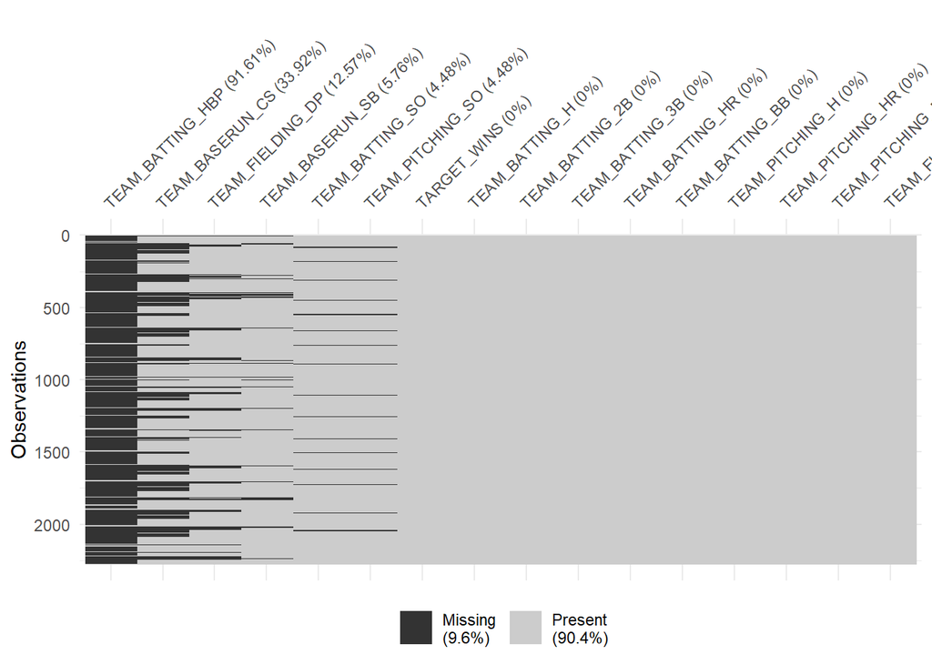

```r
visdat::vis_miss(raw, sort_miss = TRUE)
```

TEAM_BATTING_HBP`is comprised of almost 92% missing values. This variable cannot provide much information to our model.`TEAM_BASERUN`CS` also displays a very high fraction of missing values, at 34%.

We will drop `TEAM_BATTING_HBP` due to incompleteness.

```r
raw<-raw%>%select(-TEAM_BATTING_HBP)
```

Examining the shape and spread of each variable:

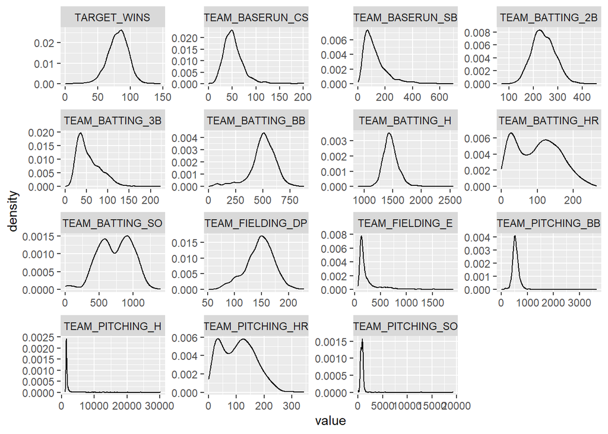

```r
raw %>%
  gather() %>%
  ggplot(aes(value)) +
  facet_wrap(~ key, scales = "free") +
  geom_density()
```

Density plots for each variable reveals the highly skewed shapes of `TEAM_FIELDING_E`, `TEAM_PITCHING_BB`, `TEAM_PITCHING_H`, AND `TEAM_PITCHING_SO` as suggested by the numeric summary above. `TEAM_BASERUN_SB` and `TEAM_BATTING_3B` display moderate skewness. Other distributions appear roughly normal or bimodal. Let’s look more closely at each of the highly skewed variables with a shapiro wilk normality test:

```r
shap<-lapply(raw,shapiro.test)
res <- sapply(shap, `[`, c("statistic","p.value"))
res
```

```
##           TARGET_WINS  TEAM_BATTING_H TEAM_BATTING_2B TEAM_BATTING_3B
## statistic 0.988248     0.9104077      0.9963224       0.9179955
## p.value   1.006842e-12 1.145863e-34   2.408015e-05    1.8063e-33
##           TEAM_BATTING_HR TEAM_BATTING_BB TEAM_BATTING_SO TEAM_BASERUN_SB
## statistic 0.9619353       0.9378385       0.9809301       0.830944
## p.value   5.232703e-24    7.302396e-30    1.807381e-16    6.620076e-43
##           TEAM_BASERUN_CS TEAM_PITCHING_H TEAM_PITCHING_HR TEAM_PITCHING_BB
## statistic 0.8696043       0.2461101       0.9715163        0.6605698
## p.value   1.176157e-33    3.673509e-70    7.284096e-21     2.31042e-55
##           TEAM_PITCHING_SO TEAM_FIELDING_E TEAM_FIELDING_DP
## statistic 0.3154772        0.6271848       0.9875677
## p.value   2.960949e-67     5.21485e-57     4.183658e-12
```

as you can see from the p-values of the Shapiro Wilk test. No variable is over alpha=.05, therefore none qualify as normally distributed. We will correct this after we are done creating new variables as to not disturb some correlations.

We’re also interested in uncovering any correlations between variables, since these could impact the performance of a linear model.

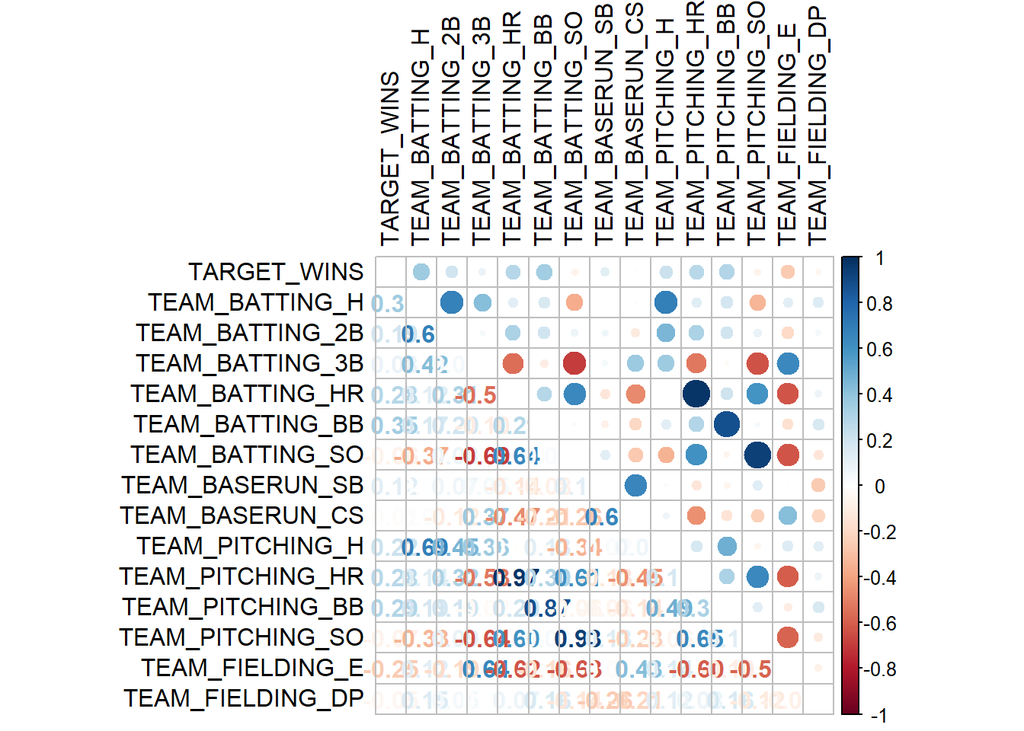

```r
raw<-raw%>%na.omit()
correlation <- cor(raw)
corrplot.mixed(correlation, tl.col = 'black', tl.pos = 'lt')
```

## Interpreting Correlation

An unexpected and concerning finding in our exploration is that the variables `TEAM_BATTING_SO` and `TEAM_PITCHING_SO` segment into groups, three of which of which exhibits a very high correlation.

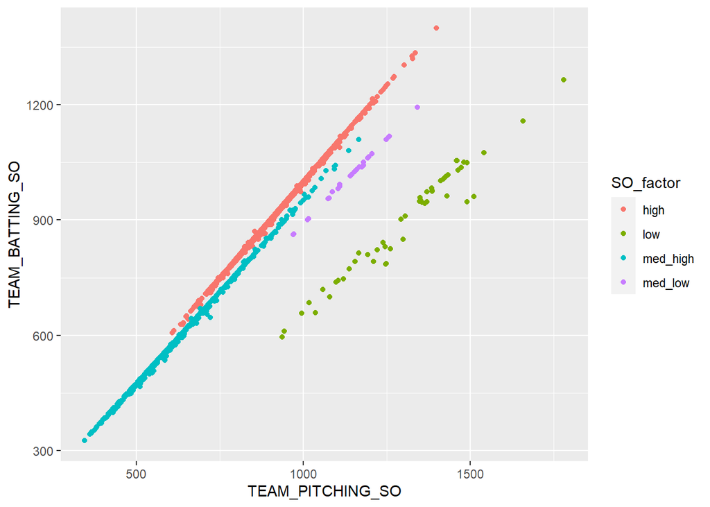

```r
raw %>%
  mutate(SO_factor = case_when(TEAM_BATTING_SO >= TEAM_PITCHING_SO*.96+10~ 'high',
                              (TEAM_BATTING_SO<TEAM_PITCHING_SO*.96+10 & TEAM_BATTING_SO>TEAM_PITCHING_SO*.96-50) ~'med_high',
                              (TEAM_BATTING_SO<TEAM_PITCHING_SO*.96-50 & TEAM_BATTING_SO>TEAM_PITCHING_SO*.96-120) ~'med_low',
                              TEAM_BATTING_SO<TEAM_PITCHING_SO*.96-120 ~'low')) %>%
  filter(TEAM_PITCHING_SO < 2000) %>%
  ggplot(aes(x = TEAM_PITCHING_SO, y = TEAM_BATTING_SO, colour = SO_factor)) +
  geom_point()
```

There is no theoretical reason to expect such high correlations between the number of strikeouts a team incurs while batting, and the number of strikeouts a team achieves while pitching. However, it may be useful to divide the data into the four groups suggested by these relationships for purposes of analysis.

# Tidying and Creating variables

Our exploration of the data suggests the following transformations:

```r
names(raw) <- gsub('TEAM_', '', x = names(raw))
```

Add variables based on groupings of `TEAM_BATTING_SO` AND `TEAM_PITCHING_SO`

```r
raw <- raw %>% mutate(SO_factor = case_when(BATTING_SO >= PITCHING_SO*.96+10 ~ 'high',
                                           (BATTING_SO<PITCHING_SO*.96+10 & BATTING_SO>PITCHING_SO*.96-50) ~'med_high',
                                           (BATTING_SO<PITCHING_SO*.96-50 & BATTING_SO>PITCHING_SO*.96-120) ~'med_low',
                                           BATTING_SO<PITCHING_SO*.96-120 ~'low'))
```

Construct new variables to reduce the number of pairs of correlated variables :

```r
raw <- raw %>%
  mutate("BASERUN_NET_SB" = BASERUN_SB - BASERUN_CS) %>%
  mutate("OFFENSE_OBP" = (BATTING_H + BATTING_BB)/(BATTING_H + BATTING_BB  + (162*27))) %>%
  mutate("DEFENSE_OBP" = (PITCHING_H  + PITCHING_BB )/(PITCHING_H  + PITCHING_BB  + (162*27))) %>%
  mutate("TOT_AT_BATS" = BATTING_H + BATTING_BB - BASERUN_CS + (162*27))
```

```r
raw <- raw %>%
  select(-c(BASERUN_SB,
            BASERUN_CS,
            BATTING_H,
            BATTING_BB,
            PITCHING_H,
            PITCHING_BB,
            )
  )
```

Still have to drop one of {BAT_HR, PITCH_HR}, {BAT_SO, PITCH_SO}, {OFFENSE_OBP, TOT_AT_BAT}

```r
#raw<-raw%>%na.omit()
pruned <- raw %>%
  select(-c(BATTING_HR,
            BATTING_SO,
            TOT_AT_BATS))
```

dropping rows with NA

```r
raw<-raw%>%na.omit()
```

Note the correlation between `OFFENSE_OBP` and `DEFENSE_OBP`

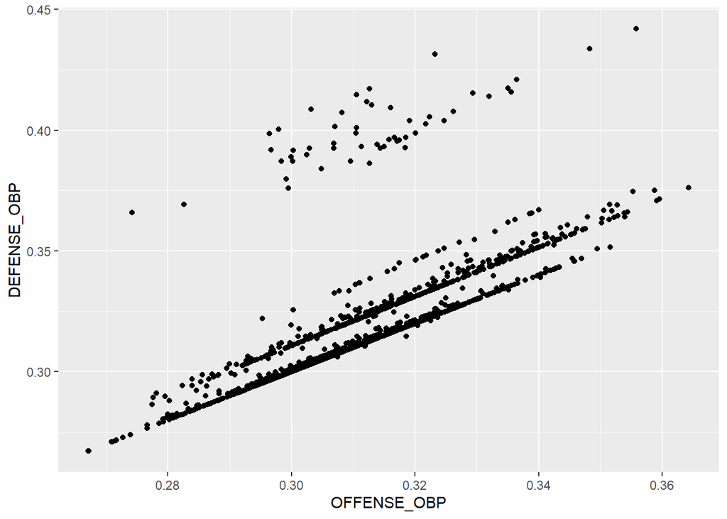

```r
ggplot(raw,aes(x=OFFENSE_OBP,y=DEFENSE_OBP))+geom_point()
```

```r
pruned<-pruned%>% relocate(SO_factor, .after = last_col())
```

There seems to be highly linear correlation with the same spread as the one we found in `PITCHING_SO` and `BATTING_SO`, which bodes well for our theory on multiple groups in the data.

# Modeling

As a first step, we will make conduct a linear regression on all of our variables and examine the results.

```r
#normalizing data as a requirement for linear regression


lambdas<-getLambda(pruned[-11])
dat<-normaliseData(pruned[-11],lambdas)
lm1 <- lm(TARGET_WINS ~ ., data = dat)
summary(lm1)
```

```
##
## Call:
## lm(formula = TARGET_WINS ~ ., data = dat)
##
## Residuals:
##     Min      1Q  Median      3Q     Max
## -33.019  -6.722   0.020   6.782  32.619
##
## Coefficients:
##                  Estimate Std. Error t value Pr(>|t|)
## (Intercept)     16.847169   8.155037   2.066    0.039 *
## BATTING_2B      -0.075908   0.008076  -9.399  < 2e-16 ***
## BATTING_3B       0.159504   0.019589   8.143 8.14e-16 ***
## PITCHING_HR      0.079329   0.008769   9.046  < 2e-16 ***
## PITCHING_SO     -0.018564   0.002142  -8.666  < 2e-16 ***
## FIELDING_E      -0.123551   0.009187 -13.448  < 2e-16 ***
## FIELDING_DP     -0.122236   0.013345  -9.160  < 2e-16 ***
## BASERUN_NET_SB   0.051061   0.009038   5.650 1.92e-08 ***
## OFFENSE_OBP    427.200670  41.394041  10.320  < 2e-16 ***
## DEFENSE_OBP    -57.643179  24.134384  -2.388    0.017 *
## ---
## Signif. codes:  0 '***' 0.001 '**' 0.01 '*' 0.05 '.' 0.1 ' ' 1
##
## Residual standard error: 9.786 on 1476 degrees of freedom
## Multiple R-squared:  0.4132, Adjusted R-squared:  0.4096
## F-statistic: 115.5 on 9 and 1476 DF,  p-value: < 2.2e-16
```

Looking at the estimates of our predictors. `OFFENSE_OBP` is the highest, meaning it is the main driver. And while all other estimates are low, their p-values are also below our alpha, so I see no need to take them out yet.

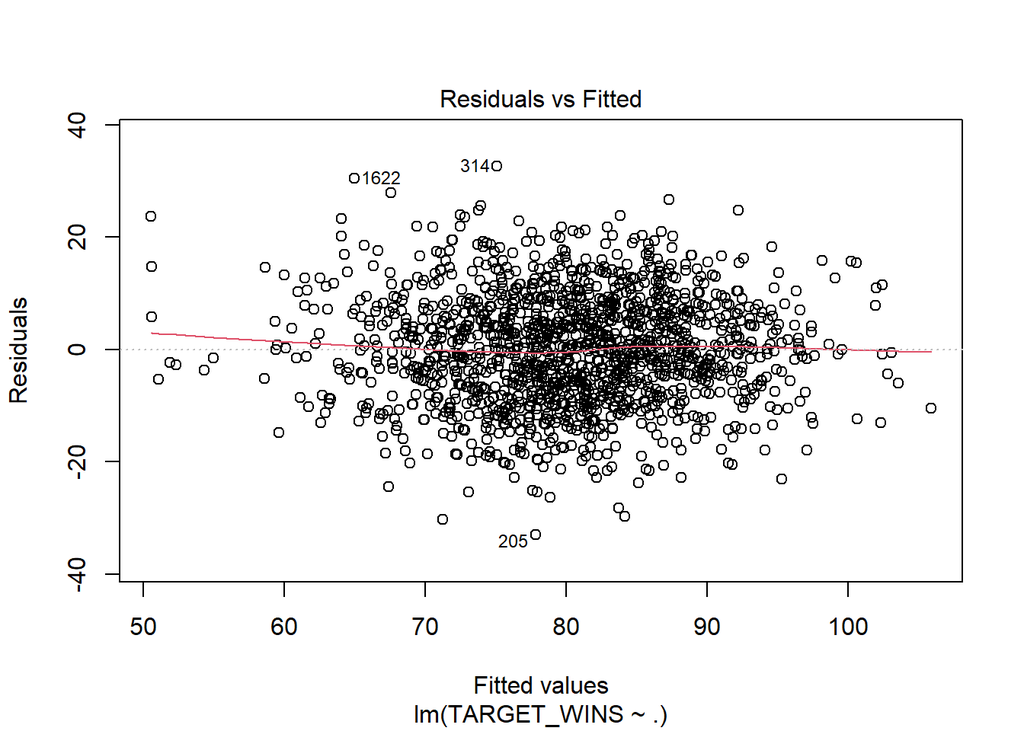

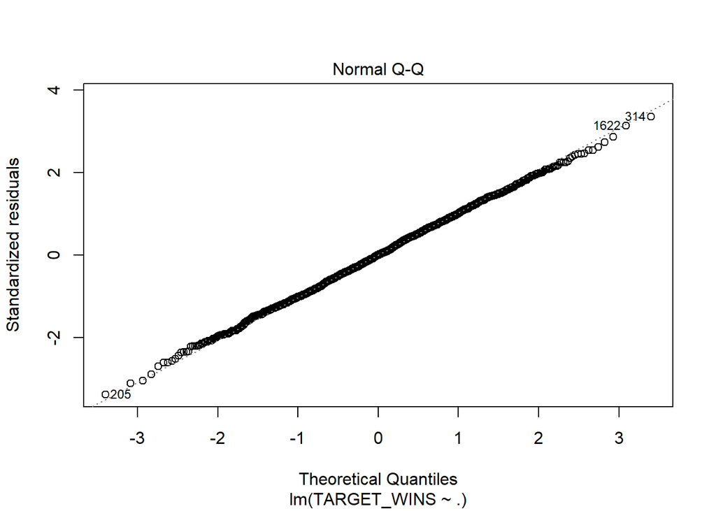

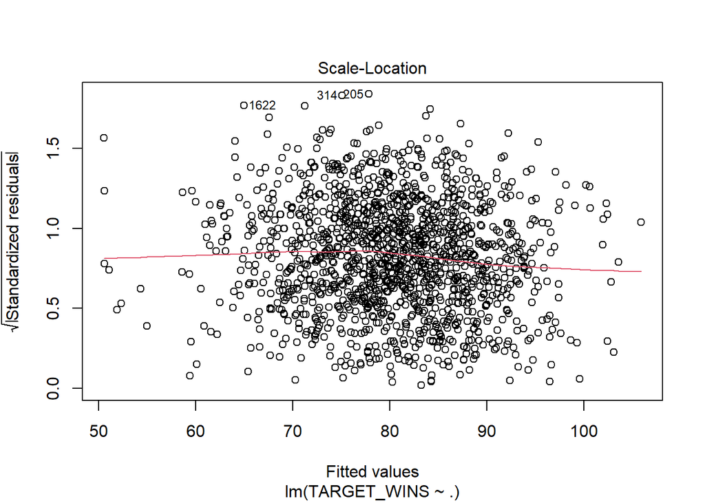

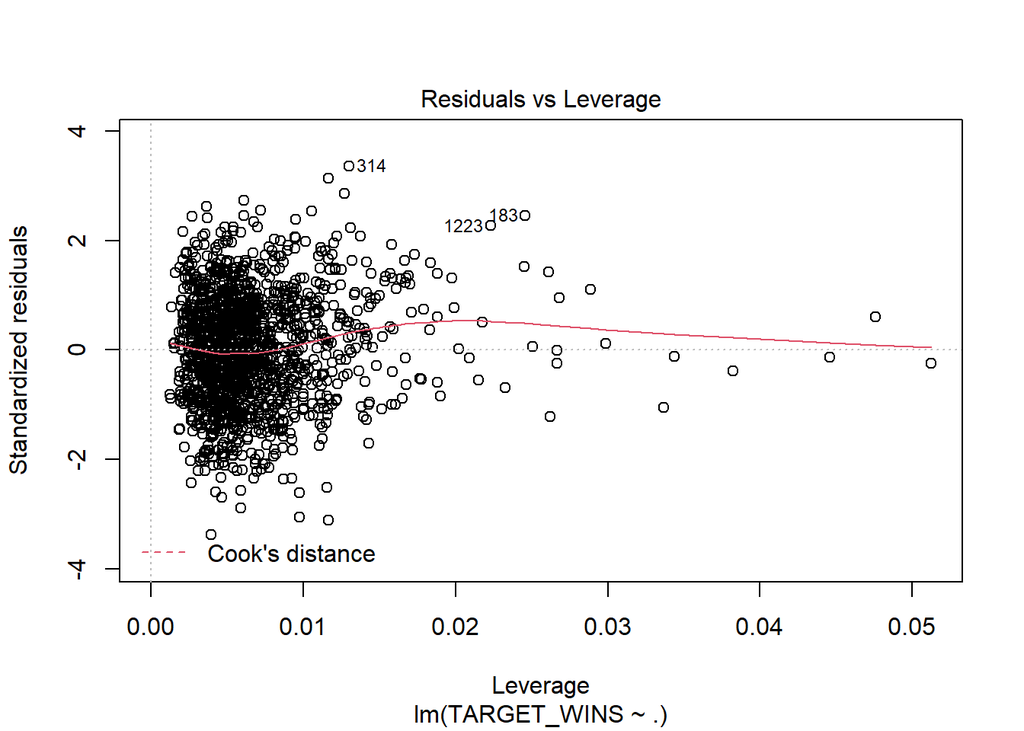

```r
plot(lm1)
```

Now we will examine the groups we identified in our `BATTING_SO` vs `PITCHING_SO` plot by first looking at the pair plot

[figure not shown]

```r
ggpairs(data=pruned,mapping=ggplot2::aes(colour = SO_factor, alpha=.2))
```

As you can see, these groups travel across variables

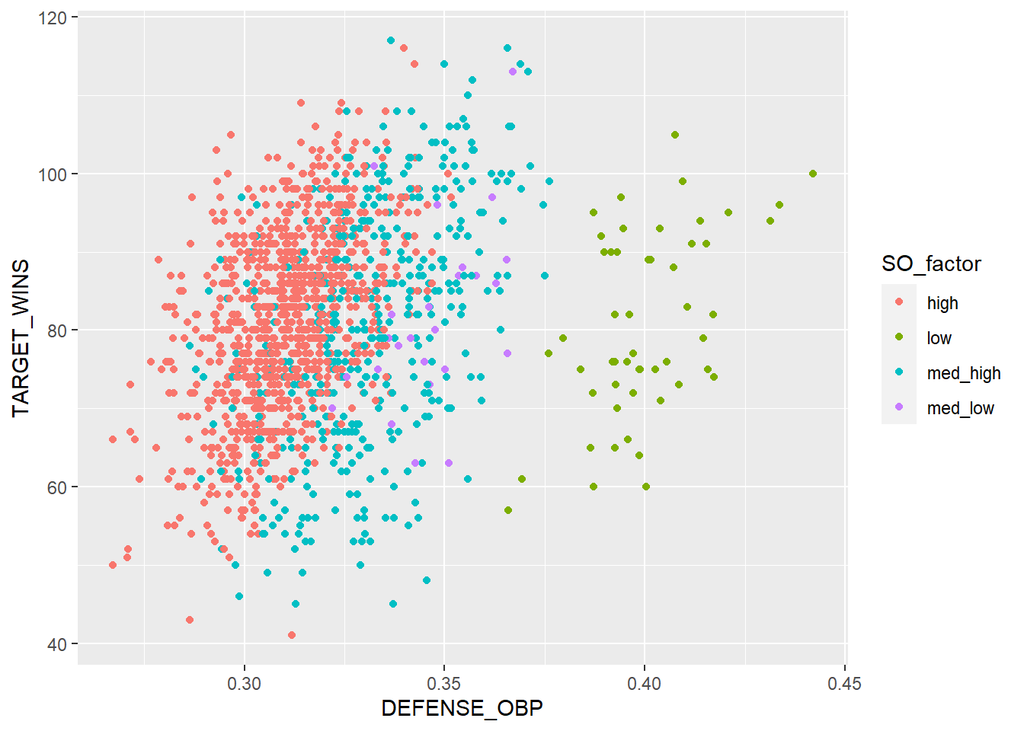

```r
ggplot(pruned, aes(x=DEFENSE_OBP,y=TARGET_WINS, color=SO_factor))+geom_point()
```

#Generating Grouped models

```r
low <- pruned %>%
  filter(SO_factor == 'low') %>%
  select(-SO_factor)
lambdas<-getLambda(low)
nlow<-normaliseData(low,lambdas)

med_low <- pruned %>%
  filter(SO_factor == "med_low") %>%
  select(-SO_factor)
lambdas<-getLambda(med_low)
nml<-normaliseData(med_low,lambdas)
med_high <- pruned %>%
  filter(SO_factor == "med_high") %>%
  select(-SO_factor)
lambdas<-getLambda(med_high)
nmh<-normaliseData(med_high,lambdas)
high <- pruned %>%
  filter(SO_factor == "high") %>%
  select(-SO_factor)
lambdas<-getLambda(high)
nhigh<-normaliseData(high,lambdas)
```

## high model

```r
lm_high <- lm(TARGET_WINS ~ ., data = high)
summary(lm_high)
```

```
##
## Call:
## lm(formula = TARGET_WINS ~ ., data = high)
##
## Residuals:
##      Min       1Q   Median       3Q      Max
## -28.0173  -6.1399  -0.1779   6.1646  24.1323
##
## Coefficients:
##                  Estimate Std. Error t value Pr(>|t|)
## (Intercept)     2.451e+01  9.849e+00   2.489   0.0130 *
## BATTING_2B     -7.698e-02  1.043e-02  -7.379 3.48e-13 ***
## BATTING_3B      1.371e-01  3.075e-02   4.458 9.25e-06 ***
## PITCHING_HR     7.085e-02  1.118e-02   6.335 3.65e-10 ***
## PITCHING_SO    -2.080e-02  2.815e-03  -7.387 3.28e-13 ***
## FIELDING_E     -1.448e-01  1.534e-02  -9.439  < 2e-16 ***
## FIELDING_DP    -1.025e-01  1.641e-02  -6.247 6.31e-10 ***
## BASERUN_NET_SB  3.992e-02  9.799e-03   4.074 5.01e-05 ***
## OFFENSE_OBP     1.011e+03  3.933e+02   2.570   0.0103 *
## DEFENSE_OBP    -6.479e+02  3.931e+02  -1.648   0.0997 .
## ---
## Signif. codes:  0 '***' 0.001 '**' 0.01 '*' 0.05 '.' 0.1 ' ' 1
##
## Residual standard error: 9.119 on 953 degrees of freedom
## Multiple R-squared:  0.3914, Adjusted R-squared:  0.3856
## F-statistic:  68.1 on 9 and 953 DF,  p-value: < 2.2e-16
```

## combined medium model

```r
tmp <- pruned %>%
  mutate("two_lev" = ifelse(SO_factor %in% c("low", "med_low"), 1, 0)) %>%
  select(-SO_factor)
tmp_lm <- lm(TARGET_WINS ~ ., data = tmp)
summary(tmp_lm)
```

```
##
## Call:
## lm(formula = TARGET_WINS ~ ., data = tmp)
##
## Residuals:
##     Min      1Q  Median      3Q     Max
## -32.702  -6.880  -0.147   6.610  31.460
##
## Coefficients:
##                  Estimate Std. Error t value Pr(>|t|)
## (Intercept)     25.862881   8.035887   3.218  0.00132 **
## BATTING_2B      -0.072913   0.008027  -9.083  < 2e-16 ***
## BATTING_3B       0.170937   0.021311   8.021 2.12e-15 ***
## PITCHING_HR      0.079907   0.008726   9.157  < 2e-16 ***
## PITCHING_SO     -0.018934   0.002303  -8.221 4.37e-16 ***
## FIELDING_E      -0.142485   0.009849 -14.467  < 2e-16 ***
## FIELDING_DP     -0.124176   0.013233  -9.384  < 2e-16 ***
## BASERUN_NET_SB   0.052266   0.008480   6.164 9.15e-10 ***
## OFFENSE_OBP    308.782477  44.722991   6.904 7.47e-12 ***
## DEFENSE_OBP     39.492301  34.191267   1.155  0.24826
## two_lev         -2.576336   2.623893  -0.982  0.32632
## ---
## Signif. codes:  0 '***' 0.001 '**' 0.01 '*' 0.05 '.' 0.1 ' ' 1
##
## Residual standard error: 9.691 on 1475 degrees of freedom
## Multiple R-squared:  0.4211, Adjusted R-squared:  0.4172
## F-statistic: 107.3 on 10 and 1475 DF,  p-value: < 2.2e-16
```

# models

```r
lm_low <- lm(TARGET_WINS ~ ., data = low)
lm_med_low <- lm(TARGET_WINS ~ ., data = med_low)
lm_med_high <- lm(TARGET_WINS ~ ., data = med_high)
lm_high <- lm(TARGET_WINS ~ ., data = high)

summary(lm_low)
```

```
##
## Call:
## lm(formula = TARGET_WINS ~ ., data = low)
##
## Residuals:
##      Min       1Q   Median       3Q      Max
## -14.1565  -6.0339  -0.1424   5.8926  18.4397
##
## Coefficients:
##                  Estimate Std. Error t value Pr(>|t|)
## (Intercept)     3.744e+01  4.281e+01   0.875   0.3867
## BATTING_2B     -5.306e-04  4.139e-02  -0.013   0.9898
## BATTING_3B      7.091e-02  1.341e-01   0.529   0.5997
## PITCHING_HR     4.033e-02  3.597e-02   1.121   0.2686
## PITCHING_SO    -2.115e-02  1.052e-02  -2.011   0.0508 .
## FIELDING_E     -2.061e-01  7.673e-02  -2.686   0.0103 *
## FIELDING_DP    -1.273e-01  7.217e-02  -1.764   0.0850 .
## BASERUN_NET_SB  2.715e-02  3.892e-02   0.698   0.4893
## OFFENSE_OBP    -1.476e+01  2.613e+02  -0.056   0.9552
## DEFENSE_OBP     2.720e+02  1.997e+02   1.362   0.1803
## ---
## Signif. codes:  0 '***' 0.001 '**' 0.01 '*' 0.05 '.' 0.1 ' ' 1
##
## Residual standard error: 8.815 on 42 degrees of freedom
## Multiple R-squared:  0.5508, Adjusted R-squared:  0.4545
## F-statistic: 5.722 on 9 and 42 DF,  p-value: 3.699e-05
```

```r
summary(lm_med_low)
```

```
##
## Call:
## lm(formula = TARGET_WINS ~ ., data = med_low)
##
## Residuals:
##     Min      1Q  Median      3Q     Max
## -18.320  -6.853  -0.761   6.269  17.911
##
## Coefficients:
##                  Estimate Std. Error t value Pr(>|t|)
## (Intercept)    -2.721e+01  1.187e+02  -0.229   0.8217
## BATTING_2B      3.346e-02  1.094e-01   0.306   0.7640
## BATTING_3B     -1.038e-01  3.117e-01  -0.333   0.7437
## PITCHING_HR     1.620e-01  7.041e-02   2.300   0.0362 *
## PITCHING_SO    -1.181e-02  3.129e-02  -0.377   0.7113
## FIELDING_E     -4.561e-02  1.709e-01  -0.267   0.7933
## FIELDING_DP    -1.219e-01  1.318e-01  -0.925   0.3697
## BASERUN_NET_SB  4.187e-02  8.029e-02   0.521   0.6097
## OFFENSE_OBP    -3.090e+03  4.729e+03  -0.653   0.5235
## DEFENSE_OBP     3.165e+03  4.579e+03   0.691   0.5000
## ---
## Signif. codes:  0 '***' 0.001 '**' 0.01 '*' 0.05 '.' 0.1 ' ' 1
##
## Residual standard error: 10.91 on 15 degrees of freedom
## Multiple R-squared:  0.4578, Adjusted R-squared:  0.1324
## F-statistic: 1.407 on 9 and 15 DF,  p-value: 0.2685
```

```r
summary(lm_med_high)
```

```
##
## Call:
## lm(formula = TARGET_WINS ~ ., data = med_high)
##
## Residuals:
##     Min      1Q  Median      3Q     Max
## -32.443  -7.709  -0.180   7.283  31.963
##
## Coefficients:
##                  Estimate Std. Error t value Pr(>|t|)
## (Intercept)     1.774e+01  1.682e+01   1.055 0.292162
## BATTING_2B     -6.840e-02  1.771e-02  -3.863 0.000129 ***
## BATTING_3B      2.127e-01  3.659e-02   5.813 1.18e-08 ***
## PITCHING_HR     9.320e-02  1.732e-02   5.380 1.22e-07 ***
## PITCHING_SO    -1.552e-02  5.738e-03  -2.705 0.007108 **
## FIELDING_E     -1.386e-01  1.670e-02  -8.301 1.31e-15 ***
## FIELDING_DP    -1.572e-01  2.577e-02  -6.099 2.36e-09 ***
## BASERUN_NET_SB  8.757e-02  2.344e-02   3.736 0.000212 ***
## OFFENSE_OBP     5.379e+02  3.178e+02   1.692 0.091289 .
## DEFENSE_OBP    -1.681e+02  3.033e+02  -0.554 0.579669
## ---
## Signif. codes:  0 '***' 0.001 '**' 0.01 '*' 0.05 '.' 0.1 ' ' 1
##
## Residual standard error: 10.81 on 436 degrees of freedom
## Multiple R-squared:  0.4825, Adjusted R-squared:  0.4718
## F-statistic: 45.17 on 9 and 436 DF,  p-value: < 2.2e-16
```

```r
summary(lm_high)
```

```
##
## Call:
## lm(formula = TARGET_WINS ~ ., data = high)
##
## Residuals:
##      Min       1Q   Median       3Q      Max
## -28.0173  -6.1399  -0.1779   6.1646  24.1323
##
## Coefficients:
##                  Estimate Std. Error t value Pr(>|t|)
## (Intercept)     2.451e+01  9.849e+00   2.489   0.0130 *
## BATTING_2B     -7.698e-02  1.043e-02  -7.379 3.48e-13 ***
## BATTING_3B      1.371e-01  3.075e-02   4.458 9.25e-06 ***
## PITCHING_HR     7.085e-02  1.118e-02   6.335 3.65e-10 ***
## PITCHING_SO    -2.080e-02  2.815e-03  -7.387 3.28e-13 ***
## FIELDING_E     -1.448e-01  1.534e-02  -9.439  < 2e-16 ***
## FIELDING_DP    -1.025e-01  1.641e-02  -6.247 6.31e-10 ***
## BASERUN_NET_SB  3.992e-02  9.799e-03   4.074 5.01e-05 ***
## OFFENSE_OBP     1.011e+03  3.933e+02   2.570   0.0103 *
## DEFENSE_OBP    -6.479e+02  3.931e+02  -1.648   0.0997 .
## ---
## Signif. codes:  0 '***' 0.001 '**' 0.01 '*' 0.05 '.' 0.1 ' ' 1
##
## Residual standard error: 9.119 on 953 degrees of freedom
## Multiple R-squared:  0.3914, Adjusted R-squared:  0.3856
## F-statistic:  68.1 on 9 and 953 DF,  p-value: < 2.2e-16
```

Also note that there are slight differences in significance of variables between the models. We could select different variables for each group for an extra layer of optimization.

# Backwards Feature Selection

# high model

```r
nhigh<-nhigh%>%
  select(-OFFENSE_OBP)
lm_high <- lm(TARGET_WINS ~ ., data = nhigh)
summary(lm_high)
```

```
##
## Call:
## lm(formula = TARGET_WINS ~ ., data = nhigh)
##
## Residuals:
##      Min       1Q   Median       3Q      Max
## -30.4131  -6.4004   0.0005   6.2219  24.8065
##
## Coefficients:
##                  Estimate Std. Error t value Pr(>|t|)
## (Intercept)     20.921294   9.896687   2.114 0.034777 *
## BATTING_2B      -0.076414   0.010525  -7.261 8.00e-13 ***
## BATTING_3B       0.141646   0.030250   4.682 3.24e-06 ***
## PITCHING_HR      0.071396   0.011407   6.259 5.84e-10 ***
## PITCHING_SO     -0.020109   0.002825  -7.118 2.16e-12 ***
## FIELDING_E      -0.146510   0.015440  -9.489  < 2e-16 ***
## FIELDING_DP     -0.104685   0.016555  -6.324 3.92e-10 ***
## BASERUN_NET_SB   0.038159   0.009818   3.886 0.000109 ***
## DEFENSE_OBP    364.016767  32.881574  11.071  < 2e-16 ***
## ---
## Signif. codes:  0 '***' 0.001 '**' 0.01 '*' 0.05 '.' 0.1 ' ' 1
##
## Residual standard error: 9.217 on 954 degrees of freedom
## Multiple R-squared:  0.383,  Adjusted R-squared:  0.3778
## F-statistic: 74.01 on 8 and 954 DF,  p-value: < 2.2e-16
```

# combined middle model

```r
tmp<-tmp%>%
  select(-OFFENSE_OBP)
lm_high <- lm(TARGET_WINS ~ ., data =tmp)
summary(lm_high)
```

```
##
## Call:
## lm(formula = TARGET_WINS ~ ., data = tmp)
##
## Residuals:
##     Min      1Q  Median      3Q     Max
## -31.834  -7.047   0.119   6.877  32.122
##
## Coefficients:
##                  Estimate Std. Error t value Pr(>|t|)
## (Intercept)     58.445104   6.606306   8.847  < 2e-16 ***
## BATTING_2B      -0.052031   0.007552  -6.889 8.27e-12 ***
## BATTING_3B       0.167025   0.021638   7.719 2.15e-14 ***
## PITCHING_HR      0.097410   0.008481  11.486  < 2e-16 ***
## PITCHING_SO     -0.022939   0.002264 -10.133  < 2e-16 ***
## FIELDING_E      -0.150316   0.009937 -15.127  < 2e-16 ***
## FIELDING_DP     -0.121408   0.013434  -9.037  < 2e-16 ***
## BASERUN_NET_SB   0.065121   0.008402   7.750 1.69e-14 ***
## DEFENSE_OBP    229.585214  20.591389  11.150  < 2e-16 ***
## two_lev        -14.630086   1.989532  -7.354 3.19e-13 ***
## ---
## Signif. codes:  0 '***' 0.001 '**' 0.01 '*' 0.05 '.' 0.1 ' ' 1
##
## Residual standard error: 9.843 on 1476 degrees of freedom
## Multiple R-squared:  0.4024, Adjusted R-squared:  0.3987
## F-statistic: 110.4 on 9 and 1476 DF,  p-value: < 2.2e-16
```

# low model

```r
nlow<-nlow%>%
  select(TARGET_WINS,FIELDING_DP,FIELDING_E,DEFENSE_OBP)
lm_low <- lm(TARGET_WINS ~ ., data = nlow)
summary(lm_low)
```

```
##
## Call:
## lm(formula = TARGET_WINS ~ ., data = nlow)
##
## Residuals:
##      Min       1Q   Median       3Q      Max
## -18.0116  -6.7300  -0.9351   5.8377  19.6127
##
## Coefficients:
##              Estimate Std. Error t value Pr(>|t|)
## (Intercept)  -2.06478   37.87645  -0.055 0.956752
## FIELDING_DP  -0.12933    0.06376  -2.028 0.048089 *
## FIELDING_E   -0.24975    0.05959  -4.191 0.000118 ***
## DEFENSE_OBP 336.75381   84.90088   3.966 0.000242 ***
## ---
## Signif. codes:  0 '***' 0.001 '**' 0.01 '*' 0.05 '.' 0.1 ' ' 1
##
## Residual standard error: 8.786 on 48 degrees of freedom
## Multiple R-squared:  0.4891, Adjusted R-squared:  0.4572
## F-statistic: 15.32 on 3 and 48 DF,  p-value: 4.006e-07
```